# Project

## Loading the Dataset

```r
url <- "http://archive.ics.uci.edu/static/public/848/secondary+mushroom+dataset.zip"

temp_zip <- tempfile(fileext = ".zip")
temp_dir <- tempdir()

# Download and unzip the first zip
download.file(url, temp_zip, mode = "wb")
unzip(temp_zip, exdir = temp_dir)

# Unzip the nested MushroomDataset.zip
nested_zip <- file.path(temp_dir, "MushroomDataset.zip")
unzip(nested_zip, exdir = temp_dir)

# Read the secondary_data.csv with semicolon delimiter
mushroom <- read.csv(file.path(temp_dir, "MushroomDataset/secondary_data.csv"),
                     sep = ";")


# Clean up
unlink(temp_zip)
unlink(nested_zip)

# View the data
head(mushroom)
```

|  | class | cap.diameter | cap.shape | cap.surface | cap.color | does.bruise.or.bleed | gill.attachment | gill.spacing | gill.color | stem.height | stem.width | stem.root | stem.surface | stem.color | veil.type | veil.color | has.ring | ring.type | spore.print.color | habitat | season |
| --- | --- | --- | --- | --- | --- | --- | --- | --- | --- | --- | --- | --- | --- | --- | --- | --- | --- | --- | --- | --- | --- |
| 1 | p | 15.26 | x | g | o | f | e |  | w | 16.95 | 17.09 | s | y | w | u | w | t | g |  | d | w |
| 2 | p | 16.60 | x | g | o | f | e |  | w | 17.99 | 18.19 | s | y | w | u | w | t | g |  | d | u |
| 3 | p | 14.07 | x | g | o | f | e |  | w | 17.80 | 17.74 | s | y | w | u | w | t | g |  | d | w |
| 4 | p | 14.17 | f | h | e | f | e |  | w | 15.77 | 15.98 | s | y | w | u | w | t | p |  | d | w |
| 5 | p | 14.64 | x | h | o | f | e |  | w | 16.53 | 17.20 | s | y | w | u | w | t | p |  | d | w |
| 6 | p | 15.34 | x | g | o | f | e |  | w | 17.84 | 18.79 | s | y | w | u | w | t | p |  | d | u |

## Exploring the Data

```r
# structure of the data set
str(mushroom)
```

```
## 'data.frame':    61069 obs. of  21 variables:
##  $ class               : chr  "p" "p" "p" "p" ...
##  $ cap.diameter        : num  15.3 16.6 14.1 14.2 14.6 ...
##  $ cap.shape           : chr  "x" "x" "x" "f" ...
##  $ cap.surface         : chr  "g" "g" "g" "h" ...
##  $ cap.color           : chr  "o" "o" "o" "e" ...
##  $ does.bruise.or.bleed: chr  "f" "f" "f" "f" ...
##  $ gill.attachment     : chr  "e" "e" "e" "e" ...
##  $ gill.spacing        : chr  "" "" "" "" ...
##  $ gill.color          : chr  "w" "w" "w" "w" ...
##  $ stem.height         : num  16.9 18 17.8 15.8 16.5 ...
##  $ stem.width          : num  17.1 18.2 17.7 16 17.2 ...
##  $ stem.root           : chr  "s" "s" "s" "s" ...
##  $ stem.surface        : chr  "y" "y" "y" "y" ...
##  $ stem.color          : chr  "w" "w" "w" "w" ...
##  $ veil.type           : chr  "u" "u" "u" "u" ...
##  $ veil.color          : chr  "w" "w" "w" "w" ...
##  $ has.ring            : chr  "t" "t" "t" "t" ...
##  $ ring.type           : chr  "g" "g" "g" "p" ...
##  $ spore.print.color   : chr  "" "" "" "" ...
##  $ habitat             : chr  "d" "d" "d" "d" ...
##  $ season              : chr  "w" "u" "w" "w" ...
```

```r
# summary of the data set
summary(mushroom)
```

```
##     class            cap.diameter     cap.shape         cap.surface
##  Length:61069       Min.   : 0.380   Length:61069       Length:61069
##  Class :character   1st Qu.: 3.480   Class :character   Class :character
##  Mode  :character   Median : 5.860   Mode  :character   Mode  :character
##                     Mean   : 6.734
##                     3rd Qu.: 8.540
##                     Max.   :62.340
##   cap.color         does.bruise.or.bleed gill.attachment    gill.spacing
##  Length:61069       Length:61069         Length:61069       Length:61069
##  Class :character   Class :character     Class :character   Class :character
##  Mode  :character   Mode  :character     Mode  :character   Mode  :character
##
##
##
##   gill.color         stem.height       stem.width      stem.root
##  Length:61069       Min.   : 0.000   Min.   :  0.00   Length:61069
##  Class :character   1st Qu.: 4.640   1st Qu.:  5.21   Class :character
##  Mode  :character   Median : 5.950   Median : 10.19   Mode  :character
##                     Mean   : 6.582   Mean   : 12.15
##                     3rd Qu.: 7.740   3rd Qu.: 16.57
##                     Max.   :33.920   Max.   :103.91
##  stem.surface        stem.color         veil.type          veil.color
##  Length:61069       Length:61069       Length:61069       Length:61069
##  Class :character   Class :character   Class :character   Class :character
##  Mode  :character   Mode  :character   Mode  :character   Mode  :character
##
##
##
##    has.ring          ring.type         spore.print.color    habitat
##  Length:61069       Length:61069       Length:61069       Length:61069
##  Class :character   Class :character   Class :character   Class :character
##  Mode  :character   Mode  :character   Mode  :character   Mode  :character
##
##
##
##     season
##  Length:61069
##  Class :character
##  Mode  :character
##
##
##
```

```r
# check for missing values
colSums(is.na(mushroom))
```

```
##                class         cap.diameter            cap.shape
##                    0                    0                    0
##          cap.surface            cap.color does.bruise.or.bleed
##                    0                    0                    0
##      gill.attachment         gill.spacing           gill.color
##                    0                    0                    0
##          stem.height           stem.width            stem.root
##                    0                    0                    0
##         stem.surface           stem.color            veil.type
##                    0                    0                    0
##           veil.color             has.ring            ring.type
##                    0                    0                    0
##    spore.print.color              habitat               season
##                    0                    0                    0
```

```r
# check for the number of unique categories
sapply(mushroom, function(x) if(is.factor(x) || is.character(x)) length(unique(x)) else NA)
```

```
##                class         cap.diameter            cap.shape
##                    2                   NA                    7
##          cap.surface            cap.color does.bruise.or.bleed
##                   12                   12                    2
##      gill.attachment         gill.spacing           gill.color
##                    8                    4                   12
##          stem.height           stem.width            stem.root
##                   NA                   NA                    6
##         stem.surface           stem.color            veil.type
##                    9                   13                    2
##           veil.color             has.ring            ring.type
##                    7                    2                    9
##    spore.print.color              habitat               season
##                    8                    8                    4
```

The data set shows no missing columns but, from the data structure, we can observe that some features have empty string (” “) which should be treated as missing values.

## Visualization

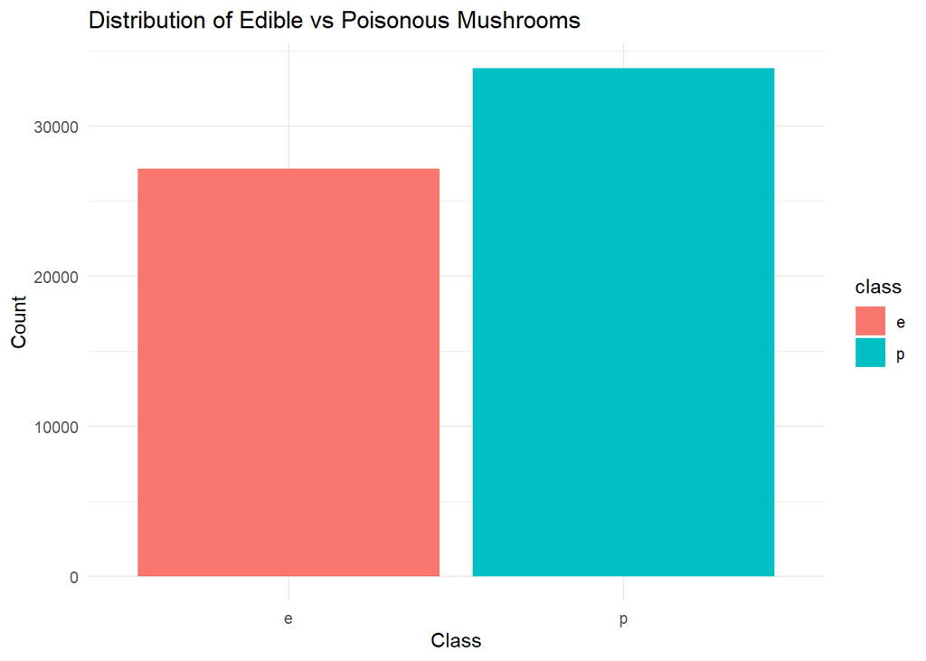

```r
library(ggplot2)

# Bar plot of edible vs poisonous
ggplot(mushroom, aes(x = class, fill = class)) +
  geom_bar() +
  labs(title = "Distribution of Edible vs Poisonous Mushrooms",
       x = "Class", y = "Count") +
  theme_minimal()
```

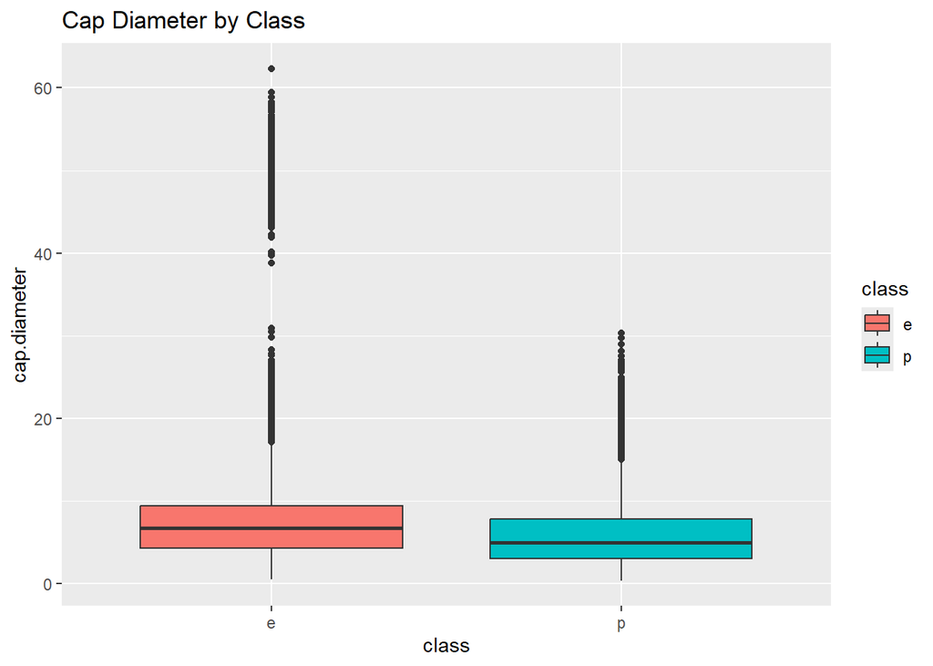

```r
# numerical columns distribution between the classes
p1 <- ggplot(mushroom, aes(x = class, y = cap.diameter, fill = class)) +
  geom_boxplot() +
  labs(title = "Cap Diameter by Class")

p2 <- ggplot(mushroom, aes(x = class, y = stem.height, fill = class)) +
  geom_boxplot() +
  labs(title = "Stem Height by Class")

p3 <- ggplot(mushroom, aes(x = class, y = stem.width, fill = class)) +
  geom_boxplot() +
  labs(title = "Stem Width by Class")

p1
```

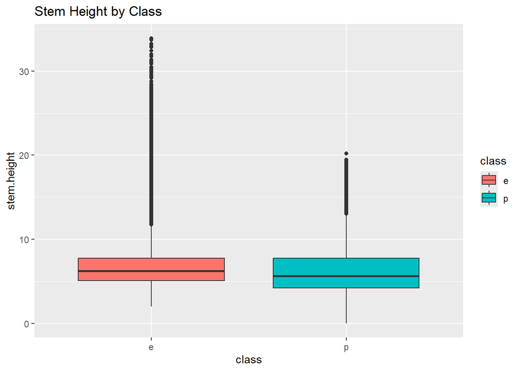

```r
p2
```

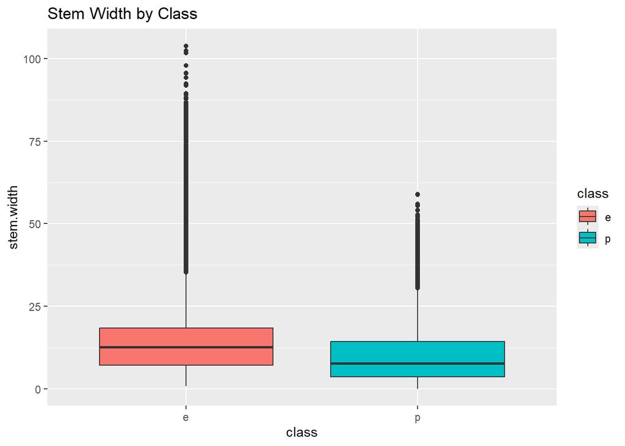

```r
p3
```

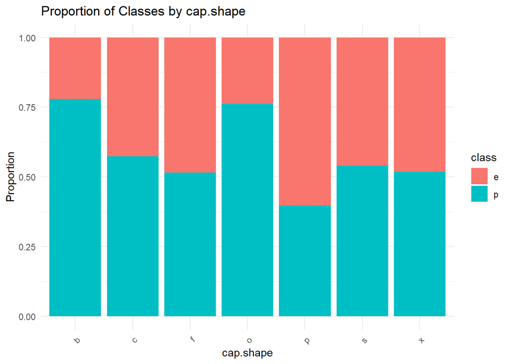

```r
# Categorical columns
# Function to create comparison plots
plot_categorical <- function(var_name) {
  ggplot(mushroom, aes_string(x = var_name, fill = "class")) +
    geom_bar(position = "fill") +
    labs(title = paste("Proportion of Classes by", var_name),
         y = "Proportion") +
    theme_minimal() +
    theme(axis.text.x = element_text(angle = 45, hjust = 1))
}

# Apply to important categorical variables
plot_categorical("cap.shape")
```

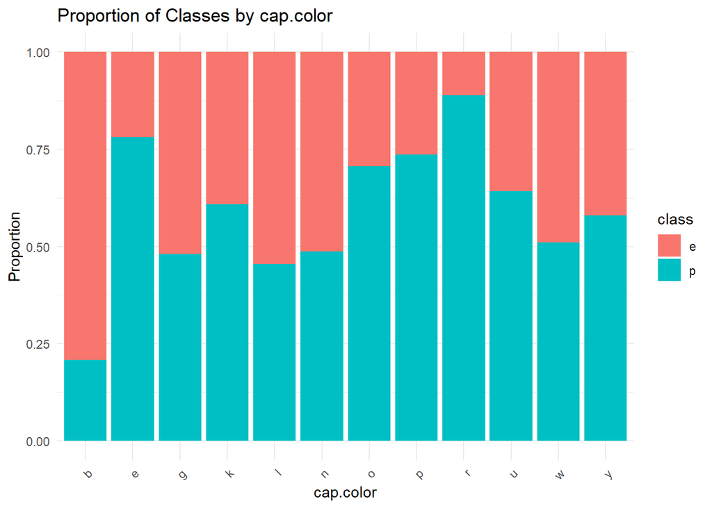

```r
plot_categorical("cap.color")
```

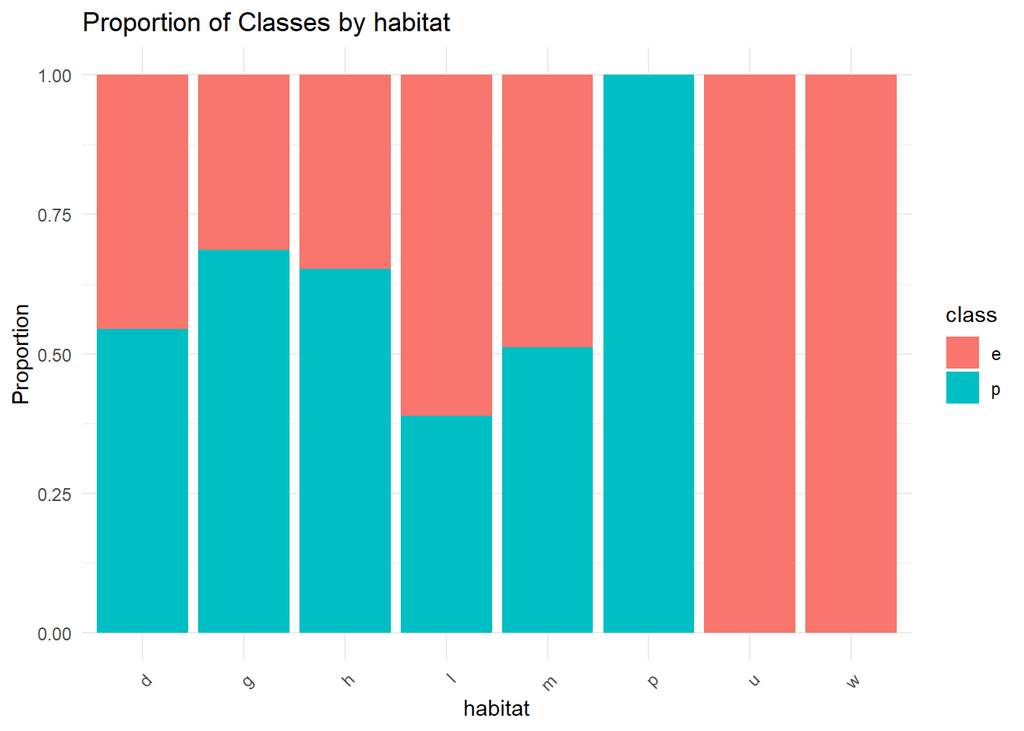

```r
plot_categorical("habitat")
```

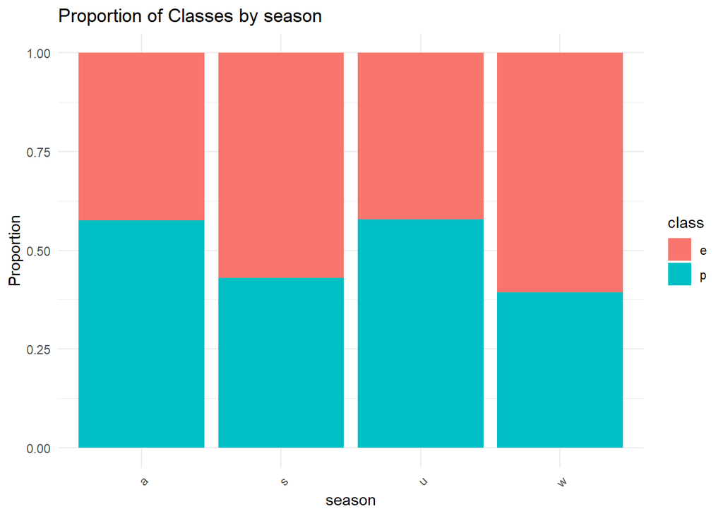

```r
plot_categorical("season")
```

## Data Cleaning

### Handling Missing values

```r
# Check for NA values
colSums(is.na(mushroom))
```

```
##                class         cap.diameter            cap.shape
##                    0                    0                    0
##          cap.surface            cap.color does.bruise.or.bleed
##                    0                    0                    0
##      gill.attachment         gill.spacing           gill.color
##                    0                    0                    0
##          stem.height           stem.width            stem.root
##                    0                    0                    0
##         stem.surface           stem.color            veil.type
##                    0                    0                    0
##           veil.color             has.ring            ring.type
##                    0                    0                    0
##    spore.print.color              habitat               season
##                    0                    0                    0
```

```r
# Replace empty strings with NA for easier handling
char_cols <- sapply(mushroom, is.character)
mushroom[char_cols] <- lapply(mushroom[char_cols], function(x) {
  x[x == ""] <- NA
  return(x)
})

# Check missing values again
colSums(is.na(mushroom))
```

```
##                class         cap.diameter            cap.shape
##                    0                    0                    0
##          cap.surface            cap.color does.bruise.or.bleed
##                14120                    0                    0
##      gill.attachment         gill.spacing           gill.color
##                 9884                25063                    0
##          stem.height           stem.width            stem.root
##                    0                    0                51538
##         stem.surface           stem.color            veil.type
##                38124                    0                57892
##           veil.color             has.ring            ring.type
##                53656                    0                 2471
##    spore.print.color              habitat               season
##                54715                    0                    0
```

Initially upon checking for missing values, all the columns show 0 NA values but, in the structure of the data we observe that few columns have empty strings (““), which are missing values. So we replaced those empty strings with NA values for easy handling.

### Imputing missing values

```r
# Median imputation of numerical columns
for(col in names(mushroom)) {
  if(is.numeric(mushroom[[col]]) && sum(is.na(mushroom[[col]])) > 0) {
    median_val <- median(mushroom[[col]], na.rm = TRUE)
    n_missing <- sum(is.na(mushroom[[col]]))
    mushroom[[col]][is.na(mushroom[[col]])] <- median_val
  }
}

# Mode imputation of categorical columns
get_mode <- function(x) {
  x <- x[!is.na(x)]
  unique_x <- unique(x)
  unique_x[which.max(tabulate(match(x, unique_x)))]
}

for(col in names(mushroom)) {
  if((is.character(mushroom[[col]]) || is.factor(mushroom[[col]])) &&
     col != "class" &&
     sum(is.na(mushroom[[col]])) > 0) {

    mode_val <- get_mode(mushroom[[col]])
    n_missing <- sum(is.na(mushroom[[col]]))
    mushroom[[col]][is.na(mushroom[[col]])] <- mode_val
  }
}

# Convert character columns to factors
for(col in names(mushroom)) {
  if(is.character(mushroom[[col]]) && col != "class") {
    mushroom[[col]] <- as.factor(mushroom[[col]])
  }
}

colSums(is.na(mushroom))
```

```
##                class         cap.diameter            cap.shape
##                    0                    0                    0
##          cap.surface            cap.color does.bruise.or.bleed
##                    0                    0                    0
##      gill.attachment         gill.spacing           gill.color
##                    0                    0                    0
##          stem.height           stem.width            stem.root
##                    0                    0                    0
##         stem.surface           stem.color            veil.type
##                    0                    0                    0
##           veil.color             has.ring            ring.type
##                    0                    0                    0
##    spore.print.color              habitat               season
##                    0                    0                    0
```

```r
sum(is.na(mushroom)) == 0
```

```
## [1] TRUE
```

### Handling Outliers

```r
# IQR Method for handling outliers
numeric_cols <- sapply(mushroom, is.numeric)

for(col in names(mushroom)[numeric_cols]) {

  # Calculate IQR
  Q1 <- quantile(mushroom[[col]], 0.25, na.rm = TRUE)
  Q3 <- quantile(mushroom[[col]], 0.75, na.rm = TRUE)
  IQR_val <- Q3 - Q1

  # Calculate bounds
  lower_bound <- Q1 - 1.5 * IQR_val
  upper_bound <- Q3 + 1.5 * IQR_val

  n_low <- sum(mushroom[[col]] < lower_bound, na.rm = TRUE)
  n_high <- sum(mushroom[[col]] > upper_bound, na.rm = TRUE)

  # Cap outliers
  if(n_low > 0 || n_high > 0) {
    mushroom[[col]][mushroom[[col]] < lower_bound] <- lower_bound
    mushroom[[col]][mushroom[[col]] > upper_bound] <- upper_bound
  }
}
```

### Correlation

```r
library(corrplot)
numeric_features <- mushroom[, sapply(mushroom, is.numeric)]

# Calculate correlation matrix
cor_matrix <- cor(numeric_features)
print(round(cor_matrix, 2))
```

```
##              cap.diameter stem.height stem.width
## cap.diameter         1.00        0.53       0.82
## stem.height          0.53        1.00       0.46
## stem.width           0.82        0.46       1.00
```

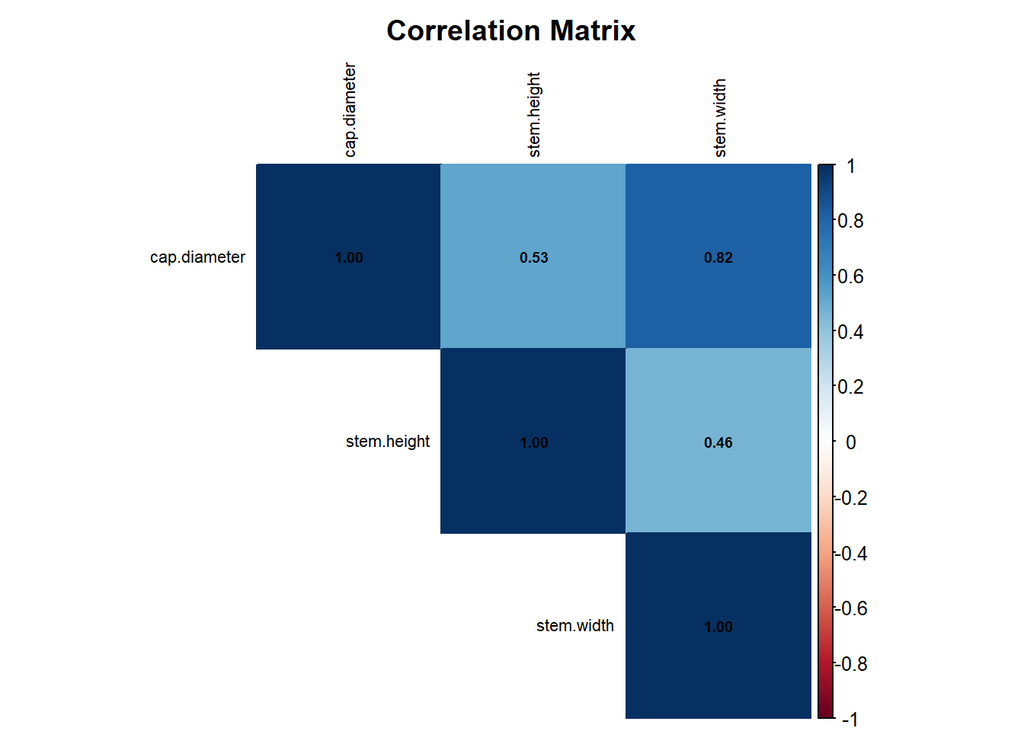

```r
# Visualize correlation matrix
corrplot(cor_matrix,
         method = "color",
         type = "upper",
         tl.col = "black",
         tl.cex = 0.7,
         addCoef.col = "black",
         number.cex = 0.6,
         title = "Correlation Matrix",
         mar = c(0, 0, 2, 0))
```

### Removing Data leakage columns

```r
# Remove perfect predictors BEFORE train-test split
perfect_predictors <- c("stem.root", "stem.surface", "stem.color",
                        "veil.color", "ring.type", "spore.print.color",
                        "habitat")

cat("\nRemoving perfect predictors to prevent data leakage:\n")
```

```
##
## Removing perfect predictors to prevent data leakage:
```

```r
print(perfect_predictors)
```

```
## [1] "stem.root"         "stem.surface"      "stem.color"
## [4] "veil.color"        "ring.type"         "spore.print.color"
## [7] "habitat"
```

```r
# Only remove if they exist in the dataset
perfect_predictors <- perfect_predictors[perfect_predictors %in% names(mushroom)]
mushroom <- mushroom[, !names(mushroom) %in% perfect_predictors]

cat("\nRemaining columns:\n")
```

```
##
## Remaining columns:
```

```r
print(names(mushroom))
```

```
##  [1] "class"                "cap.diameter"         "cap.shape"
##  [4] "cap.surface"          "cap.color"            "does.bruise.or.bleed"
##  [7] "gill.attachment"      "gill.spacing"         "gill.color"
## [10] "stem.height"          "stem.width"           "veil.type"
## [13] "has.ring"             "season"
```

### Data split

```r
library(caret)
set.seed(123)
trainIndex <- createDataPartition(mushroom$class, p = 0.7,
                                   list = FALSE, times = 1)
train <- mushroom[trainIndex, ]
test <- mushroom[-trainIndex, ]

# Verify balance
cat("Train class distribution:\n")
```

```
## Train class distribution:
```

```r
print(prop.table(table(train$class)))
```

```
##
##         e         p
## 0.4450864 0.5549136
```

```r
cat("\nTest class distribution:\n")
```

```
##
## Test class distribution:
```

```r
print(prop.table(table(test$class)))
```

```
##
##         e         p
## 0.4450873 0.5549127
```

### Encoding

```r
# One-hot encoding function (same as before)
one_hot_encode <- function(data, target_col = "class") {
  data_encoded <- data

  # Get factor columns, excluding the target
  factor_cols <- c()
  for(col_name in names(data_encoded)) {
    if(col_name != target_col && is.factor(data_encoded[[col_name]])) {
      factor_cols <- c(factor_cols, col_name)
    }
  }

  # Encode each categorical column
  if(length(factor_cols) > 0) {
    for(col in factor_cols) {
      levels_col <- levels(data_encoded[[col]])
      n_levels <- length(levels_col)

      if(n_levels > 1) {
        # Create dummy variables (dropping first level)
        for(i in 2:n_levels) {
          lvl <- levels_col[i]
          new_col <- paste0(col, "_", lvl)
          data_encoded[[new_col]] <- as.integer(data_encoded[[col]] == lvl)
        }
      }
      # Remove original column AFTER creating dummies
      data_encoded[[col]] <- NULL
    }
  }

  return(data_encoded)
}

# Apply to training data
train_encoded <- one_hot_encode(train, target_col = "class")
test_encoded <- one_hot_encode(test, target_col = "class")

train_x <- train_encoded[, names(train_encoded) != "class"]
train_y <- train_encoded$class

test_x <- test_encoded[, names(test_encoded) != "class"]
test_y <- test_encoded$class
```

### Scaling

```r
# SCALING STEP - THIS WAS MISSING!
train_mean <- sapply(train_x, mean)
train_sd   <- sapply(train_x, sd)

# Apply z-score normalization
train_x_scaled <- scale(train_x, center = train_mean, scale = train_sd)
test_x_scaled  <- scale(test_x, center = train_mean, scale = train_sd)

# Convert to data frame
train_x_scaled <- as.data.frame(train_x_scaled)
test_x_scaled  <- as.data.frame(test_x_scaled)

# Check dimensions after scaling
cat("\nDimensions after scaling:\n")
```

```
##
## Dimensions after scaling:
```

```r
cat("train_x_scaled rows:", nrow(train_x_scaled), "\n")
```

```
## train_x_scaled rows: 42749
```

```r
# Convert target to binary (1 for edible, 0 for poisonous)
train_y_binary <- as.numeric(train_y == "e")
test_y_binary <- as.numeric(test_y == "e")

# Verify dimensions match
cat("\nFinal verification:\n")
```

```
##
## Final verification:
```

```r
cat("train_x_scaled rows:", nrow(train_x_scaled), "\n")
```

```
## train_x_scaled rows: 42749
```

```r
cat("train_y_binary length:", length(train_y_binary), "\n")
```

```
## train_y_binary length: 42749
```

### Backward elimination

```r
# Convert target to binary
train_y_binary <- ifelse(train_y == "e", 0, 1)
test_y_binary <- ifelse(test_y == "e", 0, 1)


# Set significance threshold
alpha <- 0.05

current_features <- names(train_x_scaled)
eliminated_features <- c()

iteration <- 1

repeat {
  # Fit logistic regression model with current features
  current_data <- train_x_scaled[, current_features, drop = FALSE]
  current_data$TARGET <- train_y_binary

  current_model <- glm(TARGET ~ .,
                       data = current_data,
                       family = binomial(link = "logit"))

  # Get p-values from summary
  model_summary <- summary(current_model)
  coefficients_table <- model_summary$coefficients

  p_values <- coefficients_table[-1, "Pr(>|z|)"]

  # Find maximum p-value
  max_p_value <- max(p_values)
  max_p_feature <- names(which.max(p_values))

  # Check stopping condition
  if (max_p_value < alpha) {
    cat("\n All features are significant (p <", alpha, ")\n")
    break
  }

  # Remove feature with highest p-value
  eliminated_features <- c(eliminated_features, max_p_feature)
  current_features <- current_features[current_features != max_p_feature]

  iteration <- iteration + 1
}
```

```
##
##  All features are significant (p < 0.05 )
```

```r
# Store final features
final_features <- current_features
print(final_features)
```

```
##  [1] "cap.diameter"      "stem.height"       "stem.width"
##  [4] "cap.shape_c"       "cap.shape_f"       "cap.shape_o"
##  [7] "cap.shape_p"       "cap.shape_s"       "cap.shape_x"
## [10] "cap.surface_e"     "cap.surface_g"     "cap.surface_h"
## [13] "cap.surface_i"     "cap.surface_k"     "cap.surface_l"
## [16] "cap.surface_s"     "cap.surface_t"     "cap.surface_y"
## [19] "cap.color_e"       "cap.color_g"       "cap.color_k"
## [22] "cap.color_n"       "cap.color_o"       "cap.color_p"
## [25] "cap.color_r"       "cap.color_u"       "cap.color_w"
## [28] "cap.color_y"       "gill.attachment_d" "gill.attachment_e"
## [31] "gill.attachment_f" "gill.attachment_p" "gill.attachment_s"
## [34] "gill.spacing_d"    "gill.spacing_f"    "gill.color_e"
## [37] "gill.color_f"      "gill.color_g"      "gill.color_k"
## [40] "gill.color_n"      "gill.color_o"      "gill.color_p"
## [43] "gill.color_r"      "gill.color_u"      "gill.color_w"
## [46] "gill.color_y"      "has.ring_t"        "season_s"
## [49] "season_u"          "season_w"
```

```r
# updating with final features
train_x_final <- train_x_scaled[, final_features, drop = FALSE]
test_x_final <- test_x_scaled[, final_features, drop = FALSE]
```

```r
# Convert target to numeric binary (1 for edible, 0 for poisonous)
train_y_binary <- as.numeric(train_y == "e")  # 1 for edible, 0 for poisonous
test_y_binary <- as.numeric(test_y == "e")

# Verify it's numeric
print(class(train_y_binary))  # Should print "numeric"
```

```
## [1] "numeric"
```

```r
print(table(train_y_binary))   # Should show counts of 0s and 1s
```

```
## train_y_binary
##     0     1
## 23722 19027
```

```r
# Check class distribution
cat("Edible (positive, 1):", sum(train_y_binary == 1), "\n")
```

```
## Edible (positive, 1): 19027
```

```r
cat("Poisonous (negative, 0):", sum(train_y_binary == 0), "\n")
```

```
## Poisonous (negative, 0): 23722
```

```r
# Separate positive (edible) and negative (poisonous) cases
pos_idx <- which(train_y_binary == 1)  # Edible
neg_idx <- which(train_y_binary == 0)  # Poisonous

n_pos <- length(pos_idx)
n_neg <- length(neg_idx)

cat("Positive cases (edible):", n_pos, "\n")
```

```
## Positive cases (edible): 19027
```

```r
cat("Negative cases (poisonous):", n_neg, "\n")
```

```
## Negative cases (poisonous): 23722
```

```r
# Determine majority and minority
if(n_pos > n_neg) {
  # More edible, so sample from edible
  majority_idx <- pos_idx
  minority_idx <- neg_idx
  sample_size <- n_neg
} else {
  # More poisonous, so sample from poisonous
  majority_idx <- neg_idx
  minority_idx <- pos_idx
  sample_size <- n_pos
}

# Build ensemble
models <- 5
lr_models <- vector("list", models)
lr_predictions <- vector("list", models)

for(i in 1:models) {
  # Sample from majority class
  majority_sample <- sample(majority_idx, size = sample_size, replace = FALSE)
  subset_idx <- c(minority_idx, majority_sample)

  sub_train_x <- train_x_final[subset_idx, ]
  sub_train_y <- train_y_binary[subset_idx]

  # Combine for training
  train_data <- sub_train_x
  train_data$TARGET <- sub_train_y

  # Train model
  model <- glm(TARGET ~ .,
               data = train_data,
               family = binomial(link = "logit"))

  lr_models[[i]] <- model

  # Predict on test set
  lr_predictions[[i]] <- predict(model,
                                  newdata = test_x_final,
                                  type = "response")
}

# Create ensemble predictions
lr_ensemble_prob <- rowMeans(do.call(cbind, lr_predictions))

# Corrected evaluation function
ensemble_lr <- function(y_true_binary, probs, thr = 0.5) {
  # y_true_binary should already be 0/1, no conversion needed
  y_pred_binary <- as.integer(probs >= thr)

  TP <- sum(y_pred_binary == 1 & y_true_binary == 1)
  FP <- sum(y_pred_binary == 1 & y_true_binary == 0)
  FN <- sum(y_pred_binary == 0 & y_true_binary == 1)
  TN <- sum(y_pred_binary == 0 & y_true_binary == 0)

  accuracy <- (TP + TN) / (TP + TN + FP + FN)
  precision <- ifelse((TP + FP) > 0, TP / (TP + FP), 0)  # Handle division by zero
  recall <- ifelse((TP + FN) > 0, TP / (TP + FN), 0)     # Handle division by zero
  f1 <- ifelse((precision + recall) > 0,
               2 * precision * recall / (precision + recall), 0)

  return(list(Accuracy = accuracy, Precision = precision, Recall = recall, F1 = f1))
}

# Use test_y_binary (already converted) instead of test_y
results <- ensemble_lr(test_y_binary, lr_ensemble_prob, thr = 0.5)

cat("Accuracy:", round(results$Accuracy * 100, 2), "%\n")
```

```
## Accuracy: 74.21 %
```

```r
cat("Precision:", round(results$Precision, 4), "\n")
```

```
## Precision: 0.6915
```

```r
cat("Recall:", round(results$Recall, 4), "\n")
```

```
## Recall: 0.7593
```

```r
cat("F1 Score:", round(results$F1, 4), "\n")
```

```
## F1 Score: 0.7238
```